# Homework 1.

Michał Wdowski

## Introduction

The subject of this homework is to check **reproducibility** of three chosen scientific papers somehowe related to R language.

## [atable: Create Tables for Clinical Trial Reports](https://journal.r-project.org/archive/2019/RJ-2019-001/index.html)

##### *by Armin Ströbel*

The linked site of the article has a hyperlink that allows users do download supplementary materials. In the downloaded package there is a single script with all the code used in the original paper, however, lines of code in the paper are formated well enough that they can be copied directly to R IDE.

```r
# library ####
library(atable)
library(multgee)
library(survival)
```

```r
# Set classes of dataset arthritis ####
data(arthritis)

arthritis = within(arthritis, {
  score = ordered(y)
  baselinescore = ordered(baseline)
  time = paste0("Month ", time)
  sex = factor(sex, levels = c(1,2), labels = c("female", "male"))
  trt = factor(trt, levels = c(1,2), labels = c("placebo", "drug"))})
```

```r
# Apply atable: Demographics of dataset arthritis ####
the_table <- atable::atable(subset(arthritis, time=="Month 1"),
                            target_cols = c("age", "sex", "baselinescore"),
                            group_col = "trt")[1:3]
Hmisc::latex(the_table,
             file = "",
             title = "",
             label = "tab:arthritisDemographics",
             caption = "Demographics of dataset arthritis.",
             caption.lot = "Demographics of dataset arthritis",
             rowname = NULL,
             where = "!htbp",
             booktabs = TRUE,
             multicol = FALSE )
```

```
## %latex.default(the_table, file = "", title = "", label = "tab:arthritisDemographics",     caption = "Demographics of dataset arthritis.", caption.lot = "Demographics of dataset arthritis",     rowname = NULL, where = "!htbp", booktabs = TRUE, multicol = FALSE)%
## \begin{table}[!htbp]
## \caption[Demographics of dataset arthritis]{Demographics of dataset arthritis.\label{tab:arthritisDemographics}}
## \begin{center}
## \begin{tabular}{lll}
## \toprule
## Group&placebo&drug\tabularnewline
## \midrule
## Observations &&\tabularnewline
## \quad \quad&149&153\tabularnewline
## age \quad&&\tabularnewline
## \quad Mean (SD)&51 (11)&50 (11)\tabularnewline
## \quad valid (missing)&149 (0)&153 (0)\tabularnewline
## sex &&\tabularnewline
## \quad female&29\% (43)&26\% (40)\tabularnewline
## \quad male&71\% (106)&74\% (113)\tabularnewline
## \quad missing&0\% (0)&0\% (0)\tabularnewline
## baselinescore &&\tabularnewline
## \quad 1&7.4\% (11)&7.8\% (12)\tabularnewline
## \quad 2&23\% (35)&25\% (38)\tabularnewline
## \quad 3&47\% (70)&45\% (69)\tabularnewline
## \quad 4&19\% (28)&18\% (28)\tabularnewline
## \quad 5&3.4\% (5)&3.9\% (6)\tabularnewline
## \quad missing&0\% (0)&0\% (0)\tabularnewline
## \bottomrule
## \end{tabular}\end{center}
## \end{table}
```

```r
# Apply atable: Hypothesis tests of dataset arthritis ####
the_table <- atable::atable(score ~ trt | time, arthritis)


Hmisc::latex(the_table,
             file = "",
             title = "",
             label = "tab:arthritisHypothesisTests",
             caption = "Hypothesis tests of dataset arthritis.",
             caption.lot = "Hypothesis tests of dataset arthritis",
             rowname = NULL,
             where = "!htbp",
             booktabs = TRUE,
             multicol = FALSE)
```

```
## %latex.default(the_table, file = "", title = "", label = "tab:arthritisHypothesisTests",     caption = "Hypothesis tests of dataset arthritis.", caption.lot = "Hypothesis tests of dataset arthritis",     rowname = NULL, where = "!htbp", booktabs = TRUE, multicol = FALSE)%
## \begin{table}[!htbp]
## \caption[Hypothesis tests of dataset arthritis]{Hypothesis tests of dataset arthritis.\label{tab:arthritisHypothesisTests}}
## \begin{center}
## \begin{tabular}{llllll}
## \toprule
## Group&placebo&drug&p&stat&Effect Size (CI)\tabularnewline
## \midrule
## Month 1  &&&&&\tabularnewline
## \quad Observations \quad&&&&&\tabularnewline
## \quad \quad \quad&149&153&&&\tabularnewline
## \quad score \quad&&&&&\tabularnewline
## \quad \quad 1&6\% (9)&1.3\% (2)&0.08&9.9e+03&-0.12 (-0.24; 0.0017)\tabularnewline
## \quad \quad 2&23\% (35)&10\% (16)&&&\tabularnewline
## \quad \quad 3&34\% (50)&50\% (77)&&&\tabularnewline
## \quad \quad 4&30\% (45)&33\% (51)&&&\tabularnewline
## \quad \quad 5&6\% (9)&3.3\% (5)&&&\tabularnewline
## \quad \quad missing&0.67\% (1)&1.3\% (2)&&&\tabularnewline
## Month 3  &&&&&\tabularnewline
## \quad Observations \quad&&&&&\tabularnewline
## \quad \quad \quad&149&153&&&\tabularnewline
## \quad score \quad&&&&&\tabularnewline
## \quad \quad 1&6\% (9)&2\% (3)&0.0065&9e+03&-0.2 (-0.32; -0.08)\tabularnewline
## \quad \quad 2&21\% (32)&18\% (27)&&&\tabularnewline
## \quad \quad 3&42\% (63)&34\% (52)&&&\tabularnewline
## \quad \quad 4&24\% (36)&33\% (50)&&&\tabularnewline
## \quad \quad 5&5.4\% (8)&10\% (16)&&&\tabularnewline
## \quad \quad missing&0.67\% (1)&3.3\% (5)&&&\tabularnewline
## Month 5  &&&&&\tabularnewline
## \quad Observations \quad&&&&&\tabularnewline
## \quad \quad \quad&149&153&&&\tabularnewline
## \quad score \quad&&&&&\tabularnewline
## \quad \quad 1&5.4\% (8)&1.3\% (2)&0.004&8.7e+03&-0.22 (-0.34; -0.1)\tabularnewline
## \quad \quad 2&19\% (29)&13\% (20)&&&\tabularnewline
## \quad \quad 3&35\% (52)&33\% (51)&&&\tabularnewline
## \quad \quad 4&32\% (48)&29\% (45)&&&\tabularnewline
## \quad \quad 5&6.7\% (10)&18\% (28)&&&\tabularnewline
## \quad \quad missing&1.3\% (2)&4.6\% (7)&&&\tabularnewline
## \bottomrule
## \end{tabular}\end{center}
## \end{table}
```

```r
# Define replacement functions ####

new_two_sample_htest_numeric <- function(value, group, ...){

  d <- data.frame(value = value, group = group)
  group_levels <- levels(group)
  x <- subset(d, group %in% group_levels[1], select = "value", drop = TRUE)
  y <- subset(d, group %in% group_levels[2], select = "value", drop = TRUE)

  ks_test_out <- stats::ks.test(x, y)
  t_test_out <- stats::t.test(x, y)

  out <- list(p_ks = ks_test_out$p.value,
              p_t = t_test_out$p.value )

  return(out)
}
```

```r
new_statistics_numeric <- function(x, ...){

  statistics_out <- list(Median = median(x, na.rm = TRUE),
                         MAD = mad(x, na.rm = TRUE),
                         Mean = mean(x, na.rm = TRUE),
                         SD = sd(x, na.rm = TRUE))

  class(statistics_out) <- c("statistics_numeric", class(statistics_out))
  # We will need this new class later to specify the format
  return(statistics_out)
}
```

```r
new_format_statistics_numeric <- function(x, ...){

  Median_MAD <- paste(round(c(x$Median, x$MAD), digits = 1), collapse = "; ")
  Mean_SD <- paste(round(c(x$Mean, x$SD), digits = 1), collapse = "; ")

  out <- data.frame(
    tag = factor(c("Median; MAD", "Mean; SD"), levels = c("Median; MAD", "Mean; SD")),
    # the factor needs levels for the non-alphabetical order
    value = c(Median_MAD, Mean_SD),
    stringsAsFactors = FALSE)
  return(out)
}
```

```r
# Replace two_sample_htest.numeric in atable's namespace
utils::assignInNamespace(x = "two_sample_htest.numeric",
                         value = new_two_sample_htest_numeric,
                         ns = "atable")
```

```r
# set statistics.numeric in atable_options
atable_options('statistics.numeric' = new_statistics_numeric)
```

```r
# Apply atable with replaced methods ####
the_table <- atable(age ~ trt, arthritis,
                    format_statistics.statistics_numeric = new_format_statistics_numeric)
Hmisc::latex(the_table,
             file = "",
             title = "",
             label = "tab:modifynumeric",
             caption = "Modified atable now calculates the median, MAD, t-test and KS-test for numeric variables.
               The median is greater than the mean in both the drug and placebo group, which indicates a skewed distribution of age.
              Additionally the KS-test is significant, while the t-test is not.",
             caption.lot = "Modified atable",
             rowname = NULL,
             where  ="!htbp",
             booktabs = TRUE,
             multicol = FALSE)
```

```
## %latex.default(the_table, file = "", title = "", label = "tab:modifynumeric",     caption = "Modified atable now calculates the median, MAD, t-test and KS-test for numeric variables.\n               The median is greater than the mean in both the drug and placebo group, which indicates a skewed d…
## \begin{table}[!htbp]
## \caption[Modified atable]{Modified atable now calculates the median, MAD, t-test and KS-test for numeric variables.
##                The median is greater than the mean in both the drug and placebo group, which indicates a skewed distribution of age.
##               Additionally the KS-test is significant, while the t-test is not.\label{tab:modifynumeric}}
## \begin{center}
## \begin{tabular}{lllll}
## \toprule
## Group&placebo&drug&p\_ks&p\_t\tabularnewline
## \midrule
## Observations &&&&\tabularnewline
## \quad \quad&447&459&&\tabularnewline
## age \quad&&&&\tabularnewline
## \quad Median; MAD&55; 10.4&53; 10.4&0.043&0.38\tabularnewline
## \quad Mean; SD&50.7; 11.2&50.1; 11&&\tabularnewline
## \bottomrule
## \end{tabular}\end{center}
## \end{table}
```

```r
# atable on empty data frames with placeholders ####

# create empty data.frame with non-empty column names
E <- atable::test_data[FALSE, ]

stats_placeholder <- function(x, ...){

  return(list(Mean = "X.xx",
              SD = "X.xx"))
}

the_table <- atable::atable(E, target_cols = c("Numeric", "Factor"),
                            statistics.numeric = stats_placeholder)

Hmisc::latex(the_table,
             file = "",
             title = "",
             label = "tab:empty df and placeholder",
             caption = "atable applied to an empty data frame with placeholder statistics for numeric variables. The placeholder-function is applied to the numeric variable, printing X.xx in the table. The empty factor variable is summarized in the same way as non-empty factors: by returning percentages and counts; in this case yielding 0/0 = NaN percent and counts of 0 in every category, as expected. Note, that the empty data frame still needs non-empty column names.",
             caption.lot = "atable applied to an empty data frame with placeholder statistics",
             rowname = NULL,
             where = "!htbp",
             booktabs = TRUE,
             multicol = FALSE)
```

```
## %latex.default(the_table, file = "", title = "", label = "tab:empty df and placeholder",     caption = "atable applied to an empty data frame with placeholder statistics for numeric variables. The placeholder-function is applied to the numeric variable, printing X.xx in the table. The empty facto…
## \begin{table}[!htbp]
## \caption[atable applied to an empty data frame with placeholder statistics]{atable applied to an empty data frame with placeholder statistics for numeric variables. The placeholder-function is applied to the numeric variable, printing X.xx in the table. The empty factor variable is summarized in …
## \begin{center}
## \begin{tabular}{ll}
## \toprule
## Group&value\tabularnewline
## \midrule
## Observations &\tabularnewline
## \quad \quad&0\tabularnewline
## Numeric \quad&\tabularnewline
## \quad Mean&X.xx\tabularnewline
## \quad SD&X.xx\tabularnewline
## Factor &\tabularnewline
## \quad G3&NaN\% (0)\tabularnewline
## \quad G2&NaN\% (0)\tabularnewline
## \quad G1&NaN\% (0)\tabularnewline
## \quad G0&NaN\% (0)\tabularnewline
## \quad missing&NaN\% (0)\tabularnewline
## \bottomrule
## \end{tabular}\end{center}
## \end{table}
```

```r
# Add new methods for class surv ####


statistics.Surv <- function(x, ...){

  survfit_object <- survival::survfit(x ~ 1)

  # copy from survival:::print.survfit:
  out <- survival:::survmean(survfit_object, rmean = "common")

  return(list(mean_survival_time = out$matrix["*rmean"],
              SE = out$matrix["*se(rmean)"]))
}

two_sample_htest.Surv <- function(value, group, ...){


  survdiff_result <- survival::survdiff(value~group, rho=0)

  # copy from survival:::print.survdiff:
  etmp <- survdiff_result$exp
  df <- (sum(1 * (etmp > 0))) - 1
  p <- 1 - stats::pchisq(survdiff_result$chisq, df)

  return(list(p = p,
              stat = survdiff_result$chisq))
}
```

```r
# Set classes of dataset ovarian ####

ovarian <- within(survival::ovarian, {
  time_to_event = survival::Surv(futime, fustat)})

# Apply atable with new methods ####
the_table <- atable(ovarian, target_cols = c("time_to_event"), group_col = "rx")

Hmisc::latex(the_table,
            file = "",
            title = "",
            label = "tab:ovarianHypothesisTests",
            caption = "Hypothesis tests of dataset ovarian.",
            caption.lot = "Hypothesis tests of dataset ovarian",
            rowname = NULL,
            where = "!htbp",
            booktabs = TRUE,
            multicol = FALSE)
```

```
## %latex.default(the_table, file = "", title = "", label = "tab:ovarianHypothesisTests",     caption = "Hypothesis tests of dataset ovarian.", caption.lot = "Hypothesis tests of dataset ovarian",     rowname = NULL, where = "!htbp", booktabs = TRUE, multicol = FALSE)%
## \begin{table}[!htbp]
## \caption[Hypothesis tests of dataset ovarian]{Hypothesis tests of dataset ovarian.\label{tab:ovarianHypothesisTests}}
## \begin{center}
## \begin{tabular}{lllll}
## \toprule
## Group&1&2&p&stat\tabularnewline
## \midrule
## Observations &&&&\tabularnewline
## \quad \quad&13&13&&\tabularnewline
## time to event \quad&&&&\tabularnewline
## \quad mean\_survival\_time&650&889&0.3&1.1\tabularnewline
## \quad SE&120&115&&\tabularnewline
## \bottomrule
## \end{tabular}\end{center}
## \end{table}
```

A problem occured with the display od the results. Original paper probably used rnw, not rmd, because output generated, whuch was supposed to be a neat-looking table, is instead a block of Latex code. My attempts to generate it as a table in rmd - deletinmg the parts of code with latex() and atable() functions - were unsuccessful. It seems like there is some data processing as well as table converting being done at once. Nevertheless, the results is the first table seem to be the same as in the original article, but it was quite uncomfortable to search for the right columns and rows in a block of Latex code.

Likewise, copying the code into rnw didn’t work. I guess the right method is to copy and the Latex code and paste it directly into the document.

## [Estimation of Transition Probabilities for the Illness-Death Model: Package TP.idm](https://www.jstatsoft.org/article/view/v083i10)

##### *by Vanesa Balboa, Jacobo de Uña-Álvarez*

This article also has a downloadable script to be reproduced.

```r
################################################################################
### 4. Application to real data
################################################################################

library("TP.idm")
data("colonTP", package = "TP.idm")
colonTP[1:6, 1:5]
```

```
##   time1 event1 Stime event      rx
## 1   968      1  1521     1 Lev+5FU
## 2  3087      0  3087     0 Lev+5FU
## 3   542      1   963     1     Obs
## 4   245      1   293     1 Lev+5FU
## 5   523      1   659     1     Obs
## 6   904      1  1767     1 Lev+5FU
```

```r
nm01 <- TPidm(colonTP, s = 0, t = 365)
nm01
```

```
## Call:
## TPidm(data = colonTP, s = 0, t = 365)
##
## Parameters:
## s= 0
## t= 365
## Method= NM
## CI= TRUE
## CI transformation= linear
## Possible transitions:
## [1] "1 1" "1 2" "1 3"
##
## Occupation probabilities at time t:
##
##
##  transition      probs      lower     upper     variance
##         1 1 0.75242196 0.72469972 0.7801442 2.000600e-04
##         1 2 0.16361679 0.14032419 0.1869094 1.412342e-04
##         1 3 0.08396125 0.06611612 0.1018064 8.289786e-05
```

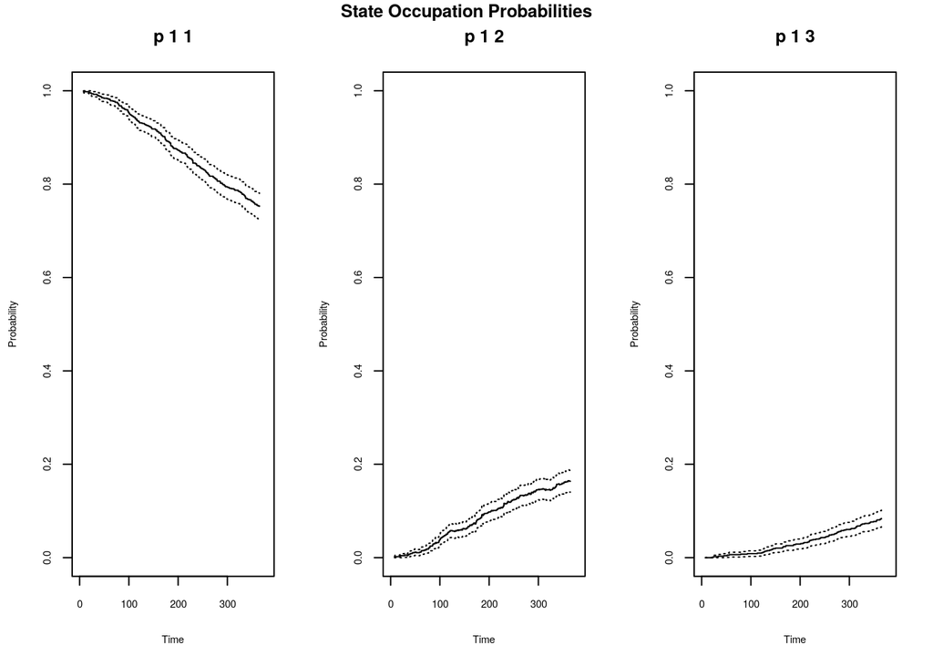

```r
plot(nm01)
```

```r
nm01$all.probs[seq(1, 194, length.out = 5), 1, ]
```

```
##      trans
## rows        1 1         1 2        1 3
##   8   0.9989236 0.001076426 0.00000000
##   122 0.9311087 0.058127018 0.01076426
##   204 0.8697524 0.100107643 0.03013994
##   279 0.8073197 0.136706136 0.05597417
##   365 0.7524220 0.163616792 0.08396125
```

```r
nm01$all.probs[nm01$times == 122, 1:4, ]
```

```
##           trans
## cols                1 1          1 2          1 3
##   probs    9.311087e-01 5.812702e-02 1.076426e-02
##   lower    9.148379e-01 4.313396e-02 4.125039e-03
##   upper    9.473795e-01 7.312008e-02 1.740349e-02
##   variance 6.891647e-05 5.851734e-05 1.147462e-05
```

```r
nm02 <- TPidm(colonTP, s = 0, t = 730)
nm12 <- TPidm(colonTP, s = 365, t = 730)
nm02
```

```
## Call:
## TPidm(data = colonTP, s = 0, t = 730)
##
## Parameters:
## s= 0
## t= 730
## Method= NM
## CI= TRUE
## CI transformation= linear
## Possible transitions:
## [1] "1 1" "1 2" "1 3"
##
## Occupation probabilities at time t:
##
##
##  transition     probs     lower     upper     variance
##         1 1 0.5994026 0.5679173 0.6308878 0.0002580580
##         1 2 0.1744163 0.1511832 0.1976494 0.0001405136
##         1 3 0.2261811 0.1992494 0.2531128 0.0001888131
```

```r
nm12
```

```
## Call:
## TPidm(data = colonTP, s = 365, t = 730)
##
## Parameters:
## s= 365
## t= 730
## Method= NM
## CI= TRUE
## CI transformation= linear
## Possible transitions:
## [1] "1 1" "1 2" "1 3" "2 2" "2 3"
##
## Transition probabilities at time t:
##
##
##  transition     probs      lower      upper     variance
##         1 1 0.7966309 0.76680585 0.82645591 2.315611e-04
##         1 2 0.1475010 0.12166865 0.17333340 1.737131e-04
##         1 3 0.0558681 0.03881836 0.07291783 7.567264e-05
##         2 2 0.3881579 0.31125428 0.46506151 1.539563e-03
##         2 3 0.6118421 0.53493849 0.68874572 1.539563e-03
```

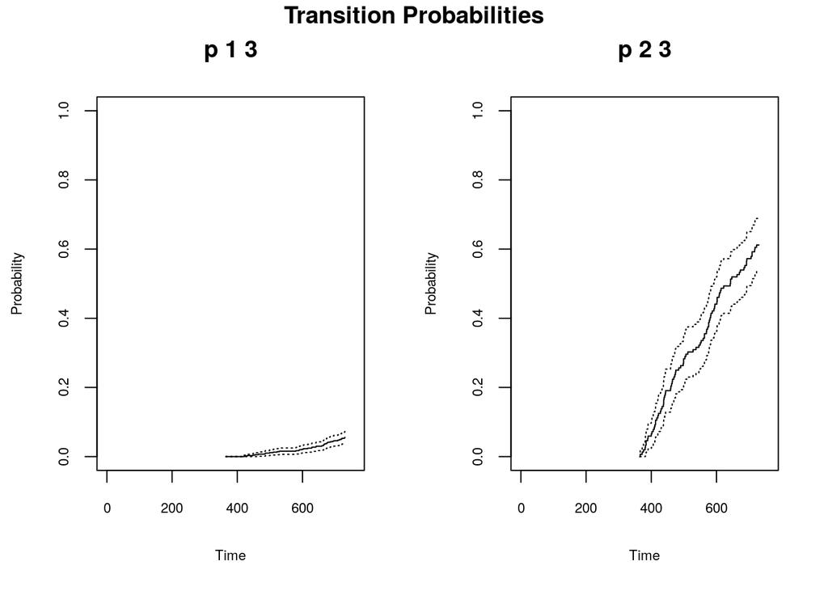

```r
plot(nm12, chosen.tr = c("1 3", "2 3"))
```

```r
nm0t_rx <- TPidm(colonTP, s = 0, cov = "rx")
nm0t_rx
```

```
## Call:
## TPidm(data = colonTP, s = 0, cov = "rx")
##
## Parameters:
## s= 0
## t:
## $t
## [1] 2789
##
## $t
## [1] 2910
##
## $t
## [1] 2725
##
##
## Covariate= rx
## Method= NM
## CI= TRUE
## CI transformation= linear
## Possible transitions:
## [1] "1 1" "1 2" "1 3"
##
## Occupation probabilities at time t:
##
##
## $probs
## $probs$Obs
##          probs     lower     upper    variance
## 1 1 0.34172071 0.2615270 0.4219144 0.001674112
## 1 2 0.06601195 0.0000000 0.1399636 0.001423638
## 1 3 0.59226734 0.5129924 0.6715423 0.001635973
##
## $probs$Lev
##           probs     lower      upper     variance
## 1 1  0.40430442 0.3481828 0.46042609 0.0008199076
## 1 2 -0.01181462 0.0000000 0.04125536 0.0007331651
## 1 3  0.60751020 0.4922649 0.72275546 0.0034574024
##
## $probs$`Lev+5FU`
##          probs     lower     upper     variance
## 1 1 0.53837372 0.4746374 0.6021101 0.0010574952
## 1 2 0.02226273 0.0000000 0.0682034 0.0005494124
## 1 3 0.43936355 0.3718034 0.5069237 0.0011881873
```

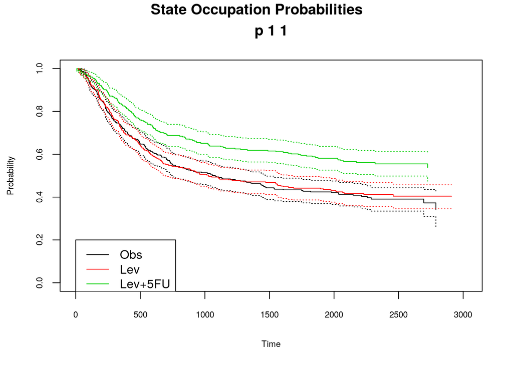

```r
plot(nm0t_rx, chosen.tr = c("1 1"), col = 1:3)
legend(0, 0.2, legend = c("Obs", "Lev", "Lev+5FU"), lty = 1, col = 1:3)
```

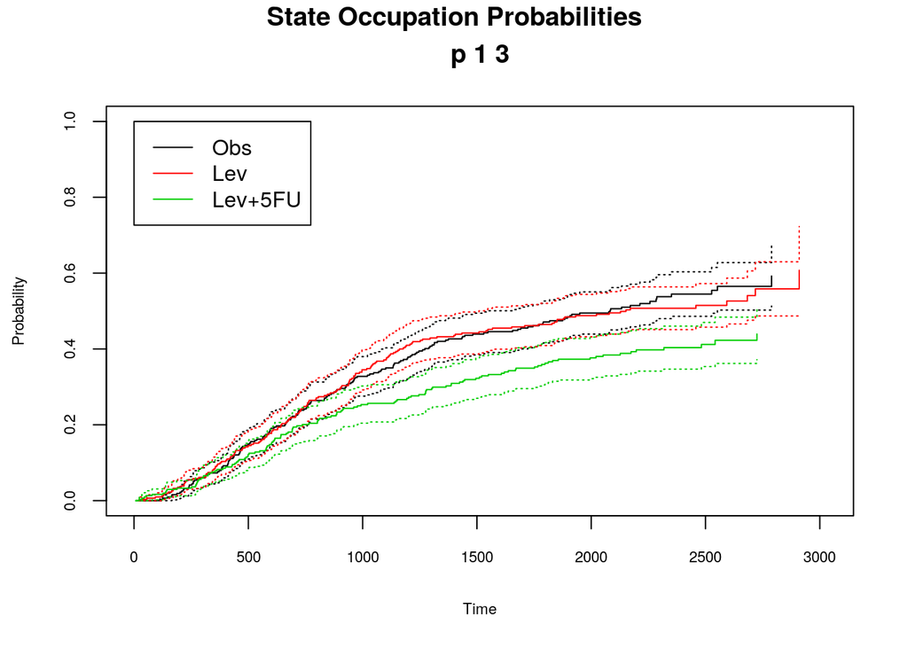

```r
plot(nm0t_rx, chosen.tr = c("1 3"), col = 1:3)
legend(0, 1, legend = c("Obs", "Lev", "Lev+5FU"), lty = 1, col = 1:3)
```

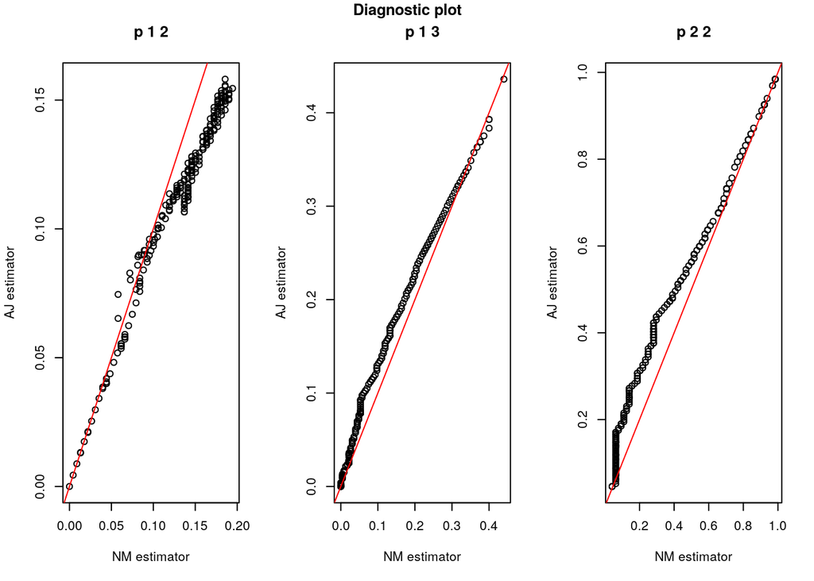

```
## Parameters:
## s= 365
## t= 2789
```

```r
test.nm(colonTP[colonTP$rx == "Obs", ], s = 365)
```

```r
library("survival")

colonTP$entrytime <- colonTP$time1
coxph(Surv(time1, Stime, event) ~ entrytime,
      data = colonTP[colonTP$time1 < colonTP$Stime & colonTP$rx == "Obs", ])
```

```
## Call:
## coxph(formula = Surv(time1, Stime, event) ~ entrytime, data = colonTP[colonTP$time1 <
##     colonTP$Stime & colonTP$rx == "Obs", ])
##
##                 coef  exp(coef)   se(coef)      z     p
## entrytime -0.0005275  0.9994726  0.0002826 -1.867 0.062
##
## Likelihood ratio test=3.53  on 1 df, p=0.06029
## n= 177, number of events= 155
```

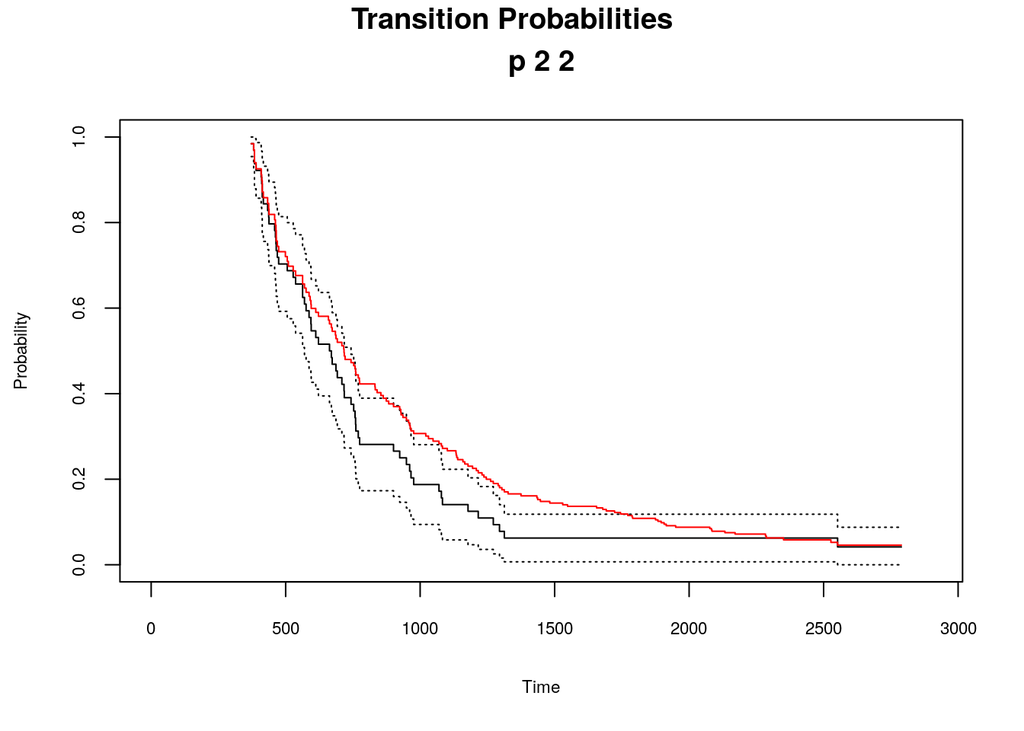

```r
plot(TPidm(colonTP[colonTP$rx == "Obs", ], s = 365), chosen.tr = c("2 2"))
aj1t.Obs <- TPidm(colonTP[colonTP$rx=="Obs", ], s = 365, method = "AJ")
lines(aj1t.Obs$times, aj1t.Obs$all.probs[, 1, 4], type = "s", col = 2)
```

```r
################################################################################
### 5. Discussion
################################################################################
### Compare computation times, TPidm() vs. etmprep() + etm().
### - colonTP data
### - continuous data
### - grouped or rounded data
################################################################################

## Allowed transitions
tra <- matrix(FALSE, 3, 3)
tra[1, 2:3] <- TRUE
tra[2, 3] <- TRUE

## Event times
timeG <- c(NA, "time1", "Stime")

## Event indicators
statusG <- c(NA, "intermediate_event", "event")

## Naming the states
state.namesG <- c("state0", "state1", "EXITUS")

AddIntermediateEvent <- function(data) {
    intermediate_event <- data$event1
    intermediate_event[data$event1 == 1 & data$event == 1 & data$time1 == data$Stime] <- 1
    intermediate_event[data$event1 == 0 | data$time1 == data$Stime] <- 0
    data$intermediate_event <- intermediate_event
    data
}

################################################################################
## colonTP data
################################################################################
data("colonTP", package = "TP.idm")
```

```r
data <- colonTP

library("TP.idm")
print(system.time(TPidm(data, s = 365, method = "AJ", CI = TRUE)))
```

```
##    user  system elapsed
##   0.803   0.020   0.823
```

```r
data <- AddIntermediateEvent(data)
keepG <- c("event", "Stime", "rx")

library("etm")
print(system.time({
    dG <- etmprep(timeG, statusG, data = data, tra, state.namesG, start = NULL, id = NULL, cens.name = "cens", keepG)
    etm(dG, state.namesG, tra, cens.name = "cens", s = 365, t = "last", covariance = TRUE)
}))
```

```
##    user  system elapsed
##   0.806   0.011   0.800
```

```r
################################################################################
## continuous data
################################################################################
for (n in c(929, 465, 233)) {
    cat("n = ", n, "\n")
    set.seed(31032017)
    T12 <- rexp(n, rate = 1)
    T13 <- rexp(n, rate = 1)
    time1.0 <- pmin(T12, T13)
    T23 <- rexp(n, rate = 2)
    Stime.0 <- time1.0 + T23 * as.numeric(T12 <= T13)
    C <- runif(n, 0, 2)
    event1 <- as.numeric(time1.0 <= C)
    time1 <- pmin(time1.0, C)
    event <- as.numeric(Stime.0 <= C)
    Stime <- pmin(Stime.0, C)

    data <- data.frame(time1, event1, Stime, event)

    library("TP.idm")
    print(system.time(TPidm(data, s = quantile(time1, probs = .15),
                            method = "AJ", CI = TRUE)))

    data <- AddIntermediateEvent(data)
    keepG <- c("event", "Stime")

    library("etm")
    print(system.time({
        dG <- etmprep(timeG, statusG, data = data, tra, state.namesG,
                      start = NULL, id = NULL, cens.name = "cens", keepG)
        etm(dG, state.namesG, tra, cens.name = "cens",
            s = quantile(time1, probs = .15), t = "last", covariance = TRUE)
    }))
}
```

```
## n =  929
##    user  system elapsed
##   0.948   0.000   0.947
##    user  system elapsed
##   0.573   0.000   0.555
## n =  465
##    user  system elapsed
##   0.432   0.000   0.432
##    user  system elapsed
##   0.404   0.000   0.392
## n =  233
##    user  system elapsed
##     0.2     0.0     0.2
##    user  system elapsed
##   0.153   0.000   0.141
```

```r
################################################################################
## grouped or rounded data
################################################################################
for (n in c(929, 465, 233)) {
    cat("n = ", n, "\n")
    set.seed(31032017)
    T12 <- round(rexp(n, rate = 1), 2)
    T13 <- round(rexp(n, rate = 1), 2)
    time1.0 <- pmin(T12, T13)
    T23 <- round(rexp(n, rate = 2), 2)

    ## To ensure entry time < exit time (so the warning of etm package
    ## is avoided).
    v <- min(time1.0[time1.0 > 0])
    u <- min(T23[T23 > 0])
    x <- min(u, v)
    time1.0 <- time1.0 + x/2
    T23 <- T23 + x/2

    Stime.0 <- time1.0 + T23 * as.numeric(T12 <= T13)

    C <- round(runif(n, 0, 2), 2)
    C <- C + x/2

    event1 <- as.numeric(time1.0 <= C)
    time1 <- pmin(time1.0, C)

    event <- as.numeric(Stime.0 <= C)
    Stime <- pmin(Stime.0, C)

    data <- as.data.frame(cbind(time1, event1, Stime, event))

    library("TP.idm")
    print(system.time(TPidm(data, s = quantile(time1, probs = .15),
                            method = "AJ", CI = TRUE)))

    data <- AddIntermediateEvent(data)
    keepG <- c("event", "Stime")

    library("etm")
    print(system.time({
        dG <- etmprep(timeG, statusG, data = data, tra, state.namesG,
                      start = NULL, id = NULL, cens.name = "cens", keepG)
        etm(dG, state.namesG, tra, cens.name = "cens",
            s = quantile(time1, probs = .15), t = "last", covariance = TRUE)
    }))
}
```

```
## n =  929
##    user  system elapsed
##   0.255   0.000   0.255
##    user  system elapsed
##   0.581   0.000   0.564
## n =  465
##    user  system elapsed
##   0.171   0.000   0.170
##    user  system elapsed
##   0.293   0.000   0.279
## n =  233
##    user  system elapsed
##   0.106   0.000   0.106
##    user  system elapsed
##   0.158   0.000   0.143
```

That article is almost flawlessly reproducible, if you ignore the proprotions of plots and some additional code in the attached script.

For some reason there was a problem with installation of one of libraries, because it had a cnoflict with Java 11 installer. If you are able to fix this problem, then you may finally use the code provided by authors.

```r
#################
# preliminaries #
#################

library("EMMIXcskew")
library("EMMIXskew")
set.seed(1)

###############################################
# Fitting a CFUST distribution - section 4.2  #
###############################################

data("iris", package = "datasets")
iris.versicolor <- subset(iris, Species == "versicolor",
  c(Sepal.Width, Petal.Length))
system.time(Fit.versicolor <- fmcfust(1, iris.versicolor, itmax = 10)) # oryginalnie itmax = 100
```

```
## Finite Mixture of Multivariate CFUST Distributions
## with 1 component
##   ----------------------------------------------------
##
##   Iteration  0 : loglik =  -144.1725
##   Iteration  1 : loglik =  -107.9638
##   Iteration  2 : loglik =  -93.01431
##   Iteration  3 : loglik =  -83.58415
##   Iteration  4 : loglik =  -77.49427
##   Iteration  5 : loglik =  -72.49087
##   Iteration  6 : loglik =  -68.87105
##   Iteration  7 : loglik =  -65.56183
##   Iteration  8 : loglik =  -63.05349
##   Iteration  9 : loglik =  -60.62724
##   Iteration  10 : loglik =  -58.73874
##   ----------------------------------------------------
##   Iteration 10: loglik = -58.73874
```

```
##    user  system elapsed
##   0.242   0.000   0.243
```

```r
summary(Fit.versicolor)
```

```
## Finite Mixture of Multivarate CFUST distributions
## with  1  component
##
## Mean:
##          [,1]
## [1,] 3.367235
## [2,] 4.847421
##
##
## Scale matrix:
## [[1]]
##            [,1]       [,2]
## [1,] 0.02187885 0.00256185
## [2,] 0.00256185 0.11084578
##
##
## Skewness matrix:
## [[1]]
##           [,1]       [,2]
## [1,] -1.227567 -0.1887226
## [2,] -1.397233 -0.1034484
##
##
##
## Degrees of freedom:
## 9.492794
```

```r
Fit.versicolor
```

```
## $pro
## [1] 1
##
## $mu
## $mu[[1]]
##          [,1]
## [1,] 3.367235
## [2,] 4.847421
##
##
## $sigma
## $sigma[[1]]
##            [,1]       [,2]
## [1,] 0.02187885 0.00256185
## [2,] 0.00256185 0.11084578
##
##
## $delta
## $delta[[1]]
##           [,1]       [,2]
## [1,] -1.227567 -0.1887226
## [2,] -1.397233 -0.1034484
##
##
## $dof
## [1] 9.492794
##
## $tau
##      [,1] [,2] [,3] [,4] [,5] [,6] [,7] [,8] [,9] [,10] [,11] [,12] [,13]
## [1,]    1    1    1    1    1    1    1    1    1     1     1     1     1
##      [,14] [,15] [,16] [,17] [,18] [,19] [,20] [,21] [,22] [,23] [,24]
## [1,]     1     1     1     1     1     1     1     1     1     1     1
##      [,25] [,26] [,27] [,28] [,29] [,30] [,31] [,32] [,33] [,34] [,35]
## [1,]     1     1     1     1     1     1     1     1     1     1     1
##      [,36] [,37] [,38] [,39] [,40] [,41] [,42] [,43] [,44] [,45] [,46]
## [1,]     1     1     1     1     1     1     1     1     1     1     1
##      [,47] [,48] [,49] [,50]
## [1,]     1     1     1     1
##
## $clusters
```

[output cut: 9 more lines]

```
##
## $iter
## [1] 10
##
## $eps
## [1] 1.888504
##
## $aic
## [1] 137.4775
##
## $bic
## [1] 156.5977
##
## attr(,"class")
## [1] "fmcfust"
```

```r
###########################################
# Fitting a FM-CFUST model - section 4.3  #
###########################################

fit.unrestricted <- fmmst(3, iris[, -5], itmax = 10) # oryginalnie itmax = 100
```

```
## Finite Mixture of Multivariate Skew t-distribution
## with  3 components
##   ----------------------------------------------------
##
##   Iteration  0 : loglik =  -199.746
##   Iteration  1 : loglik =  -195.2965
##   Iteration  2 : loglik =  -193.2354
##   Iteration  3 : loglik =  -191.6669
##   Iteration  4 : loglik =  -190.2489
##   Iteration  5 : loglik =  -188.8843
##   Iteration  6 : loglik =  -187.5491
##   Iteration  7 : loglik =  -186.2294
##   Iteration  8 : loglik =  -184.9495
##   Iteration  9 : loglik =  -183.72
##   Iteration  10 : loglik =  -182.5596
##   ----------------------------------------------------
##   Iteration 10: loglik = -182.5596
##
## Component means:
##          [,1]     [,2]      [,3]
## [1,] 6.402140 6.158029 4.8566673
## [2,] 2.853310 2.933981 3.2827288
## [3,] 5.413763 4.502946 1.3817535
## [4,] 2.168539 1.234309 0.1778033
##
##
## Component scale matrices:
## [[1]]
##            [,1]       [,2]       [,3]       [,4]
## [1,] 0.36507003 0.08452558 0.28174298 0.04633712
## [2,] 0.08452558 0.09029472 0.06355906 0.04746593
## [3,] 0.28174298 0.06355906 0.26548812 0.04455333
## [4,] 0.04633712 0.04746593 0.04455333 0.06274437
##
## [[2]]
##            [,1]       [,2]       [,3]       [,4]
## [1,] 0.23719739 0.08341998 0.18041493 0.05785510
## [2,] 0.08341998 0.07439582 0.08082892 0.04068892
## [3,] 0.18041493 0.08082892 0.19607905 0.07759644
## [4,] 0.05785510 0.04068892 0.07759644 0.04006637
##
## [[3]]
##             [,1]        [,2]       [,3]        [,4]
## [1,] 0.104569327 0.091364555 0.01578507 0.008982937
## [2,] 0.091364555 0.121036668 0.01054190 0.008160108
## [3,] 0.015785068 0.010541897 0.02345952 0.004672130
## [4,] 0.008982937 0.008160108 0.00467213 0.006496060
##
##
## Component skewness parameters:
##            [,1]       [,2]       [,3]
## [1,]  0.2307509 -0.2584005 0.18132117
## [2,]  0.1479790 -0.2024799 0.17213729
## [3,]  0.1797869 -0.2634811 0.10067860
## [4,] -0.1693505  0.1371495 0.08548577
##
##
## Component degrees of freedom:
## 40.2076 46.02692 36.02162
##
## Component mixing proportions:
## 0.3215538 0.345113 0.3333333
```

```r
fit.iris <- fmcfust(3, iris[, -5], initial = fit.unrestricted, method = "EMMIXuskew", itmax = 10) # oryginalnie itmax = 100
```

```
## Finite Mixture of Multivariate CFUST Distributions
## with  3 components
##   ----------------------------------------------------
##
##   Iteration  0 : loglik =  -182.5596
##   Iteration  1 : loglik =  -180.754
##   Iteration  2 : loglik =  -179.182
##   Iteration  3 : loglik =  -177.7448
##   Iteration  4 : loglik =  -176.4431
##   Iteration  5 : loglik =  -175.288
##   Iteration  6 : loglik =  -174.2503
##   Iteration  7 : loglik =  -173.3347
##   Iteration  8 : loglik =  -172.5061
##   Iteration  9 : loglik =  -171.7673
##   Iteration  10 : loglik =  -171.1091
##   ----------------------------------------------------
##   Iteration 10: loglik = -171.1091
```

```r
fit.iris
```

```
## $pro
## [1] 0.3539267 0.3127400 0.3333333
##
## $mu
## $mu[[1]]
##          [,1]
## [1,] 6.304678
## [2,] 2.836141
## [3,] 5.319223
## [4,] 2.127926
##
## $mu[[2]]
##          [,1]
## [1,] 6.142679
## [2,] 2.942464
## [3,] 4.432510
## [4,] 1.212282
##
## $mu[[3]]
##           [,1]
## [1,] 4.8338219
## [2,] 3.2547755
## [3,] 1.3813176
## [4,] 0.1679077
##
##
## $sigma
## $sigma[[1]]
##            [,1]       [,2]       [,3]       [,4]
## [1,] 0.35152231 0.06900520 0.26934013 0.05368518
## [2,] 0.06900520 0.08131118 0.05365867 0.04853557
## [3,] 0.26934013 0.05365867 0.25587145 0.05807952
## [4,] 0.05368518 0.04853557 0.05807952 0.06562277
##
## $sigma[[2]]
##            [,1]       [,2]       [,3]       [,4]
## [1,] 0.24854699 0.09245142 0.16795844 0.05588213
## [2,] 0.09245142 0.06692761 0.07882094 0.03904567
## [3,] 0.16795844 0.07882094 0.15037833 0.05651236
## [4,] 0.05588213 0.03904567 0.05651236 0.02964146
```

[output cut: 170 more lines]

```
##
## $iter
## [1] 10
##
## $eps
## [1] 0.6582202
##
## $aic
## [1] 532.2183
##
## $bic
## [1] 818.2286
##
## attr(,"class")
## [1] "fmcfust"
```

```r
summary(fit.iris)
```

```
## Finite Mixture of Multivarate CFUST distributions
## with  3  components
##
## Component means:
##          [,1]     [,2]      [,3]
## [1,] 6.304678 6.142679 4.8338219
## [2,] 2.836141 2.942464 3.2547755
## [3,] 5.319223 4.432510 1.3813176
## [4,] 2.127926 1.212282 0.1679077
##
##
## Component scale matrices:
## [[1]]
##            [,1]       [,2]       [,3]       [,4]
## [1,] 0.35152231 0.06900520 0.26934013 0.05368518
## [2,] 0.06900520 0.08131118 0.05365867 0.04853557
## [3,] 0.26934013 0.05365867 0.25587145 0.05807952
## [4,] 0.05368518 0.04853557 0.05807952 0.06562277
##
## [[2]]
##            [,1]       [,2]       [,3]       [,4]
## [1,] 0.24854699 0.09245142 0.16795844 0.05588213
## [2,] 0.09245142 0.06692761 0.07882094 0.03904567
## [3,] 0.16795844 0.07882094 0.15037833 0.05651236
## [4,] 0.05588213 0.03904567 0.05651236 0.02964146
##
## [[3]]
##             [,1]        [,2]        [,3]        [,4]
## [1,] 0.099757808 0.089157992 0.014235130 0.004341888
## [2,] 0.089157992 0.121530550 0.008014093 0.003398242
## [3,] 0.014235130 0.008014093 0.019309487 0.001543400
## [4,] 0.004341888 0.003398242 0.001543400 0.002517921
##
##
## Component skewness matrices:
## [[1]]
##              [,1]       [,2]        [,3]         [,4]
## [1,]  0.085882660 0.19919675  0.04560722 -0.020339269
## [2,] -0.020191041 0.20602113 -0.02990486  0.002100650
## [3,] -0.151768448 0.19204047  0.19850201 -0.008145538
```

[output cut: 8 more lines]

```
##
## [[3]]
##              [,1]        [,2]         [,3]       [,4]
## [1,]  0.179469557 -0.04277293 -0.013329981 0.09105065
## [2,] -0.011536254  0.09938867  0.026737405 0.10173133
## [3,] -0.028631914 -0.04978813  0.113705761 0.06612175
## [4,] -0.005119994 -0.01731709 -0.009091455 0.12971605
##
##
##
## Component degrees of freedom:
## 42.87184 52.22526 36.1277
##
## Component mixing proportions:
## 0.3539267 0.31274 0.3333333
```

```r
############################################################
# Nested cases of the FM-CFUST distribution - section 4.4  #
############################################################

fit.restricted <- fmcfust(3, iris[, -5], 1, itmax = 10) # oryginalnie itmax = 100
```

```
## Finite Mixture of Multivariate CFUST Distributions
## with  3 components
##   ----------------------------------------------------
##
##   Iteration  0 : loglik =  -647.449
##   Iteration  1 : loglik =  -531.484
##   Iteration  2 : loglik =  -478.0258
##   Iteration  3 : loglik =  -443.3514
##   Iteration  4 : loglik =  -419.2658
##   Iteration  5 : loglik =  -402.1234
##   Iteration  6 : loglik =  -388.5645
##   Iteration  7 : loglik =  -378.0562
##   Iteration  8 : loglik =  -368.7677
##   Iteration  9 : loglik =  -360.0733
##   Iteration  10 : loglik =  -351.9202
##   ----------------------------------------------------
##   Iteration 10: loglik = -351.9202
```

```r
table(iris$Species, fit.iris$clust)
```

```
##
##               1  2  3
##   setosa      0  0 50
##   versicolor  3 47  0
##   virginica  50  0  0
```

```r
table(iris$Species, fit.restricted$clust)
```

```
##
##               1  2  3
##   setosa     25  0 25
##   versicolor  0 50  0
##   virginica   0 50  0
```

```r
table(iris$Species, fit.unrestricted$clust)
```

```
##
##               1  2  3
##   setosa      0  0 50
##   versicolor  1 49  0
##   virginica  49  1  0
```

```r
error.rate(unclass(iris$Species), fit.iris$clust)
```

```
## [1] 0.02
```

```r
error.rate(unclass(iris$Species), fit.restricted$clust)
```

```
## [1] 0.5
```

```r
error.rate(unclass(iris$Species), fit.unrestricted$clust)
```

```
## [1] 0.01333333
```

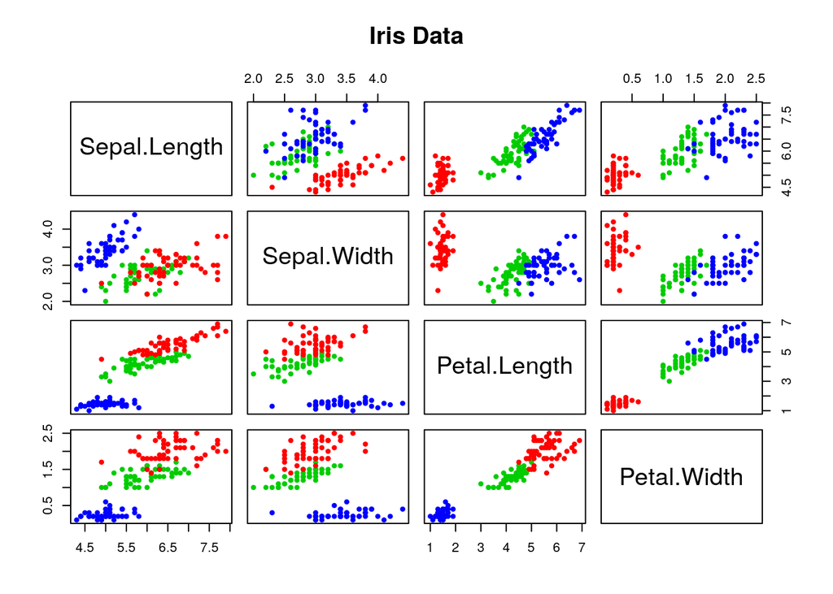

```r
panel1 <- function(x, y, ...) {
    points(x, y, col = c("red", "green3", "blue")[fit.iris$clust], pch = 20)
}
panel2 <- function(x, y, ...) {
    points(x, y, col = c("red", "green3", "blue")[fit.unrestricted$clust], pch = 20)
}
panel3 <- function(x, y, ...) {
    points(x, y, col = c("red", "green3", "blue")[fit.restricted$clust], pch = 20)
}
pairs(iris[1:4], main = "Iris Data", pch = 20, col = c("red","green3","blue")[unclass(iris$Species)], lower.panel = panel1)
```

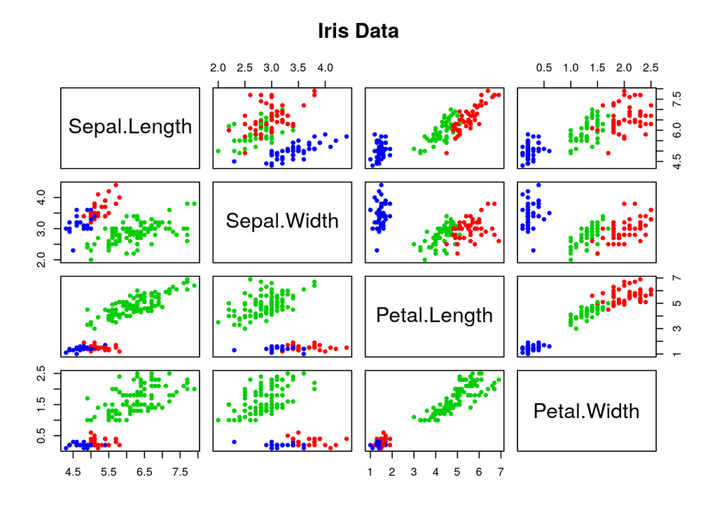

```r
pairs(iris[1:4], main = "Iris Data", upper.panel = panel2, lower.panel = panel3)
```

```r
######################################################
# Random sample from a FM-CFUST model - section 5.1  #
######################################################

RNGversion("3.1.1"); set.seed(1)
rcfust(10, c(1, 2), diag(2), matrix(c(2, 1, 1, 2), 2, 2), 4)
```

```
##            [,1]     [,2]
##  [1,]  5.836001 5.600793
##  [2,]  3.080172 4.213700
##  [3,]  3.305617 4.888012
##  [4,]  4.390739 3.109635
##  [5,]  4.003996 4.686407
##  [6,]  1.609795 1.599386
##  [7,]  3.361534 5.326190
##  [8,]  3.449745 4.474217
##  [9,] 10.886028 7.964134
## [10,]  5.752894 7.049037
```

```r
obj <- list()
obj$mu <- list(c(17, 19), c(5, 22), c(6, 10))
obj$sigma <- list(diag(2), matrix(c(2, 0, 0, 1), 2), matrix(c(3, 7, 7, 24), 2))
obj$delta <- list(matrix(c(3, 0, 2, 1.5), 2, 2), matrix(c(5, 0, 0, 10), 2, 2), matrix(c(2, 0, 5, 0), 2, 2))
obj$dof <- c(1, 2, 3)
obj$pro <- c(0.25, 0.25, 0.5)
rfmcfust(3, 100, known = obj)
```

```
##             [,1]        [,2] [,3]
##   [1,] 46.143907 25.56151304    1
##   [2,] 17.816665 18.22572581    1
##   [3,] 33.915805 25.54308697    1
##   [4,] 44.609637 15.81099978    1
##   [5,] 54.766995 16.10253015    1
##   [6,] 18.610320 19.74165026    1
##   [7,] 25.303312 20.80981782    1
##   [8,] 20.608770 21.58460735    1
##   [9,] 19.679756 20.51390429    1
##  [10,] 20.988970 16.10998335    1
##  [11,] 16.848467 18.48145959    1
##  [12,] 19.850772 19.80691216    1
##  [13,] 39.874528 25.73512774    1
##  [14,] 25.038630 20.70295229    1
```

[output cut: 86 more lines]

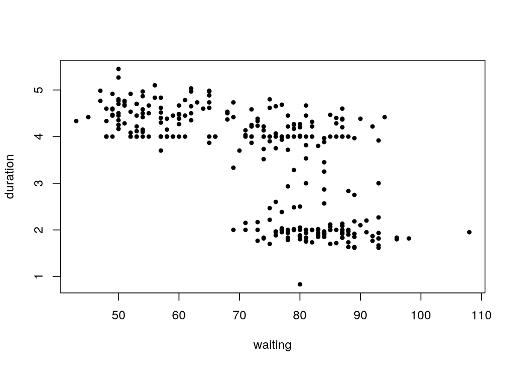

```r
#######################################################
# Starting values for a FM-CFUST model - section 5.2  #
#######################################################

data("geyser", package = "MASS")
plot(geyser, pch = 20)
```

```r
initial.default <- init.fmcfust(3, geyser)
initial.transformation <- init.fmcfust(3, geyser, method = "transformation")
fit.geyser.restricted <- EmSkew(geyser, 3, "mst", debug = FALSE)
initial.restricted <- init.fmcfust(3, geyser, initial = fit.geyser.restricted, method = "EMMIXskew")
fit.geyser.unrestricted <- fmmst(3, geyser, itmax = 10) # oryginalnie itmax = 100
```

```
## Finite Mixture of Multivariate Skew t-distribution
## with  3 components
##   ----------------------------------------------------
##
##   Iteration  0 : loglik =  -1481.589
##   Iteration  1 : loglik =  -1477.349
##   Iteration  2 : loglik =  -1474.128
##   Iteration  3 : loglik =  -1470.948
##   Iteration  4 : loglik =  -1467.463
##   Iteration  5 : loglik =  -1463.636
##   Iteration  6 : loglik =  -1459.505
##   Iteration  7 : loglik =  -1455.275
##   Iteration  8 : loglik =  -1451.123
##   Iteration  9 : loglik =  -1447.262
##   Iteration  10 : loglik =  -1443.772
##   ----------------------------------------------------
##   Iteration 10: loglik = -1443.772
##
## Component means:
##           [,1]      [,2]      [,3]
## [1,] 79.721563 80.660903 49.751976
## [2,]  4.503015  1.551135  4.092264
##
##
## Component scale matrices:
## [[1]]
##            [,1]       [,2]
## [1,]  4.5968128 -0.4201746
## [2,] -0.4201746  0.1595879
##
## [[2]]
##            [,1]        [,2]
## [1,] 13.7761559 -0.18857624
## [2,] -0.1885762  0.09263429
##
## [[3]]
##            [,1]        [,2]
## [1,] 14.0912375 -0.18311345
## [2,] -0.1831134  0.05711357
##
##
## Component skewness parameters:
##           [,1]     [,2]      [,3]
## [1,] -4.932225 6.061011 7.3201911
## [2,] -1.459070 1.370195 0.4081963
##
##
## Component degrees of freedom:
## 44.87964 39.36087 37.99719
##
## Component mixing proportions:
## 0.2792436 0.369136 0.3516204
```

```r
initial.unrestricted <- init.fmcfust(3, geyser, initial = fit.geyser.unrestricted, method = "EMMIXuskew")
fit.geyser.t <- EmSkew(geyser, 3, "mvt", debug = FALSE)
initial.t <- init.fmcfust(3, geyser, initial  = fit.geyser.t, method = "EMMIXskew")
initial.default$loglik
```

```
## [1] -1903.598
```

```r
initial.transformation$loglik
```

```
## [1] -1448.322
```

```r
initial.restricted$loglik
```

```
## [1] -1335.039
```

```r
initial.unrestricted$loglik
```

```
## [1] -1443.772
```

```r
initial.t$loglik
```

```
## [1] -1347.48
```

```r
fit.geyser1 <- fmcfust(3, geyser, initial = initial.default, itmax = 10) # oryginalnie itmax = 100
```

```
## Finite Mixture of Multivariate CFUST Distributions
## with  3 components
##   ----------------------------------------------------
##
##   Iteration  0 : loglik =  -1903.598
##   Iteration  1 : loglik =  -1723.039
##   Iteration  2 : loglik =  -1654.236
##   Iteration  3 : loglik =  -1613.936
##   Iteration  4 : loglik =  -1586.083
##   Iteration  5 : loglik =  -1565.83
##   Iteration  6 : loglik =  -1550.77
##   Iteration  7 : loglik =  -1537.995
##   Iteration  8 : loglik =  -1527.659
##   Iteration  9 : loglik =  -1518.641
##   Iteration  10 : loglik =  -1510.354
##   ----------------------------------------------------
##   Iteration 10: loglik = -1510.354
```

```r
fit.geyser2 <- fmcfust(3, geyser, initial = initial.t, itmax = 10) # oryginalnie itmax = 100
```

```
## Finite Mixture of Multivariate CFUST Distributions
## with  3 components
##   ----------------------------------------------------
##
##   Iteration  0 : loglik =  -1347.48
##   Iteration  1 : loglik =  -1347.344
##   Iteration  2 : loglik =  -1347.198
##   Iteration  3 : loglik =  -1347.046
##   Iteration  4 : loglik =  -1346.901
##   Iteration  5 : loglik =  -1346.766
##   Iteration  6 : loglik =  -1346.639
##   Iteration  7 : loglik =  -1346.521
##   Iteration  8 : loglik =  -1346.412
##   Iteration  9 : loglik =  -1346.31
##   Iteration  10 : loglik =  -1346.215
##   ----------------------------------------------------
##   Iteration 10: loglik = -1346.215
```

```r
fit.geyser3 <- fmcfust(3, geyser, initial = initial.restricted, itmax = 10) # oryginalnie itmax = 100
```

```
## Finite Mixture of Multivariate CFUST Distributions
## with  3 components
##   ----------------------------------------------------
##
##   Iteration  0 : loglik =  -1335.039
##   Iteration  1 : loglik =  -1335.011
##   Iteration  2 : loglik =  -1334.988
##   Iteration  3 : loglik =  -1334.965
##   Iteration  4 : loglik =  -1334.943
##   Iteration  5 : loglik =  -1334.921
##   Iteration  6 : loglik =  -1334.9
##   Iteration  7 : loglik =  -1334.878
##   Iteration  8 : loglik =  -1334.857
##   Iteration  9 : loglik =  -1334.836
##   Iteration  10 : loglik =  -1334.815
##   ----------------------------------------------------
##   Iteration 10: loglik = -1334.815
```

```r
fit.geyser1$loglik
```

```
## [1] -1510.354
```

```r
fit.geyser2$loglik
```

```
## [1] -1346.215
```

```r
fit.geyser3$loglik
```

```
## [1] -1334.815
```

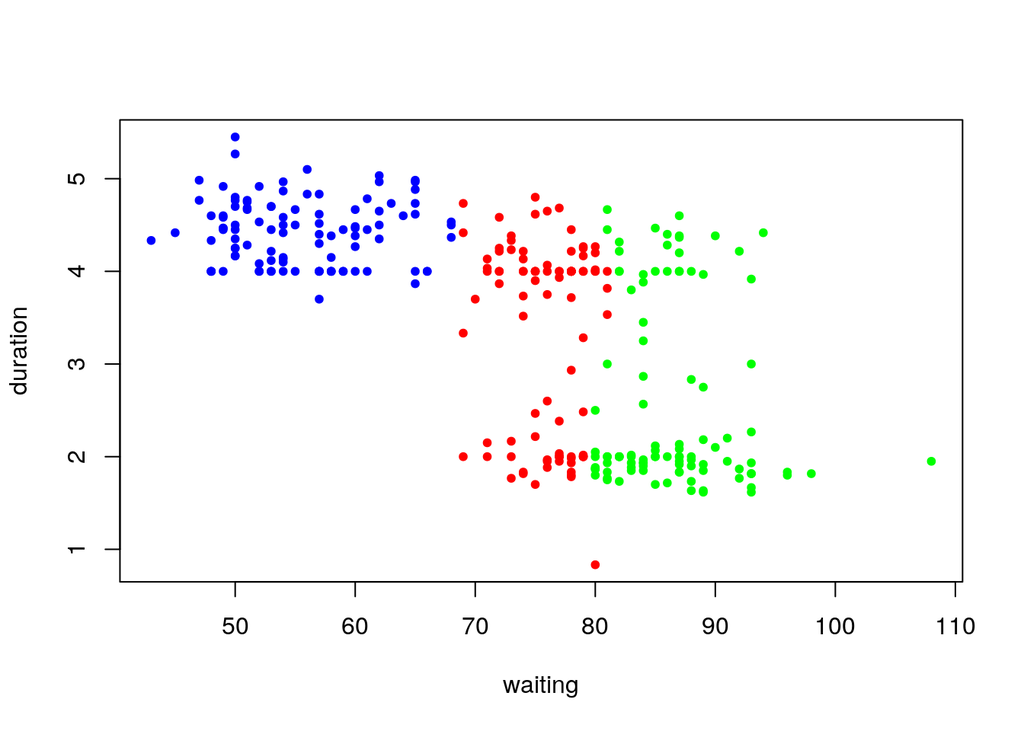

```r
plot(geyser, pch = 20, col = c("red", "blue", "green")[fit.geyser1$clust])
```

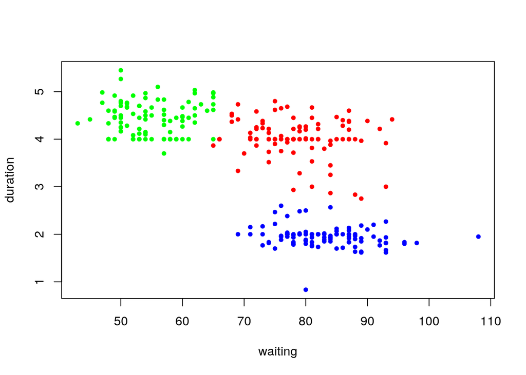

```r
plot(geyser, pch = 20, col = c("red", "blue", "green")[fit.geyser2$clust])
```

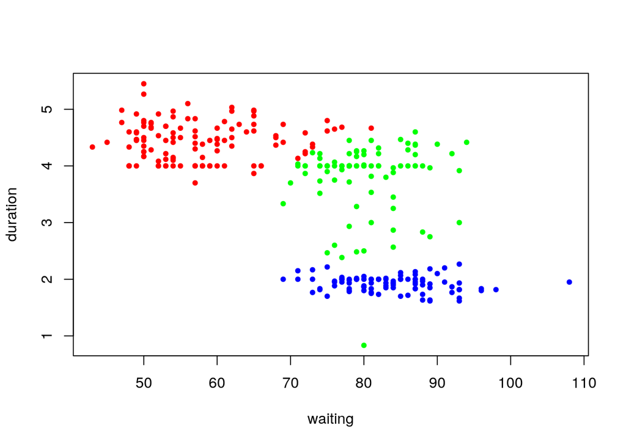

```r
plot(geyser, pch = 20, col = c("red", "blue", "green")[fit.geyser3$clust])
```

```r
#######################################################
# Stopping criteria - section 5.3                     #
#######################################################

fit.geyser4 <- fmcfust(3, geyser, initial = initial.restricted, convergence = "likelihood")
```

```
## Finite Mixture of Multivariate CFUST Distributions
## with  3 components
##   ----------------------------------------------------
##
##   Iteration  0 : loglik =  -1335.039
##   Iteration  1 : loglik =  -1335.011
##   Iteration  2 : loglik =  -1334.988
##   Iteration  3 : loglik =  -1334.965
##   Iteration  4 : loglik =  -1334.943
##   Iteration  5 : loglik =  -1334.921
##   Iteration  6 : loglik =  -1334.9
##   Iteration  7 : loglik =  -1334.878
##   Iteration  8 : loglik =  -1334.857
##   Iteration  9 : loglik =  -1334.836
##   Iteration  10 : loglik =  -1334.815
##   Iteration  11 : loglik =  -1334.795
##   Iteration  12 : loglik =  -1334.774
##   Iteration  13 : loglik =  -1334.753
##   Iteration  14 : loglik =  -1334.733
##   Iteration  15 : loglik =  -1334.712
##   Iteration  16 : loglik =  -1334.691
##   Iteration  17 : loglik =  -1334.671
##   Iteration  18 : loglik =  -1334.65
##   Iteration  19 : loglik =  -1334.63
##   Iteration  20 : loglik =  -1334.609
##   Iteration  21 : loglik =  -1334.588
##   Iteration  22 : loglik =  -1334.567
##   Iteration  23 : loglik =  -1334.546
##   Iteration  24 : loglik =  -1334.525
##   Iteration  25 : loglik =  -1334.504
##   Iteration  26 : loglik =  -1334.483
##   Iteration  27 : loglik =  -1334.461
##   Iteration  28 : loglik =  -1334.44
##   Iteration  29 : loglik =  -1334.418
##   Iteration  30 : loglik =  -1334.397
##   Iteration  31 : loglik =  -1334.375
##   Iteration  32 : loglik =  -1334.353
##   Iteration  33 : loglik =  -1334.331
##   Iteration  34 : loglik =  -1334.309
##   Iteration  35 : loglik =  -1334.287
```

[output cut: 52 more lines]

```
##   Iteration  88 : loglik =  -1333.468
##   Iteration  89 : loglik =  -1333.457
##   Iteration  90 : loglik =  -1333.445
##   Iteration  91 : loglik =  -1333.434
##   Iteration  92 : loglik =  -1333.422
##   Iteration  93 : loglik =  -1333.412
##   Iteration  94 : loglik =  -1333.402
##   Iteration  95 : loglik =  -1333.392
##   Iteration  96 : loglik =  -1333.382
##   Iteration  97 : loglik =  -1333.373
##   Iteration  98 : loglik =  -1333.365
##   Iteration  99 : loglik =  -1333.357
##   Iteration  100 : loglik =  -1333.349
##   ----------------------------------------------------
##   Iteration 100: loglik = -1333.349
```

```r
fit.geyser5 <- fmcfust(3, geyser, initial = initial.restricted, convergence = "parameters")
```

```
## Finite Mixture of Multivariate CFUST Distributions
## with  3 components
##   ----------------------------------------------------
##
##   Iteration  0 : loglik =  -1335.039
##   Iteration  1 : loglik =  -1335.011
##   Iteration  2 : loglik =  -1334.988
##   Iteration  3 : loglik =  -1334.965
##   Iteration  4 : loglik =  -1334.943
##   Iteration  5 : loglik =  -1334.921
##   Iteration  6 : loglik =  -1334.9
##   Iteration  7 : loglik =  -1334.878
##   Iteration  8 : loglik =  -1334.857
##   Iteration  9 : loglik =  -1334.836
##   Iteration  10 : loglik =  -1334.815
##   Iteration  11 : loglik =  -1334.795
##   Iteration  12 : loglik =  -1334.774
##   Iteration  13 : loglik =  -1334.753
##   Iteration  14 : loglik =  -1334.733
##   Iteration  15 : loglik =  -1334.712
##   Iteration  16 : loglik =  -1334.691
##   Iteration  17 : loglik =  -1334.671
##   Iteration  18 : loglik =  -1334.65
##   Iteration  19 : loglik =  -1334.63
##   Iteration  20 : loglik =  -1334.609
##   Iteration  21 : loglik =  -1334.588
##   Iteration  22 : loglik =  -1334.567
##   Iteration  23 : loglik =  -1334.546
##   Iteration  24 : loglik =  -1334.525
##   Iteration  25 : loglik =  -1334.504
##   Iteration  26 : loglik =  -1334.483
##   Iteration  27 : loglik =  -1334.461
##   Iteration  28 : loglik =  -1334.44
##   Iteration  29 : loglik =  -1334.418
##   Iteration  30 : loglik =  -1334.397
##   Iteration  31 : loglik =  -1334.375
##   Iteration  32 : loglik =  -1334.353
##   Iteration  33 : loglik =  -1334.331
##   Iteration  34 : loglik =  -1334.309
##   Iteration  35 : loglik =  -1334.287
```

[output cut: 52 more lines]

```
##   Iteration  88 : loglik =  -1333.468
##   Iteration  89 : loglik =  -1333.457
##   Iteration  90 : loglik =  -1333.445
##   Iteration  91 : loglik =  -1333.434
##   Iteration  92 : loglik =  -1333.422
##   Iteration  93 : loglik =  -1333.412
##   Iteration  94 : loglik =  -1333.402
##   Iteration  95 : loglik =  -1333.392
##   Iteration  96 : loglik =  -1333.382
##   Iteration  97 : loglik =  -1333.373
##   Iteration  98 : loglik =  -1333.365
##   Iteration  99 : loglik =  -1333.357
##   Iteration  100 : loglik =  -1333.349
##   ----------------------------------------------------
##   Iteration 100: loglik = -1333.349
```

```r
#######################################################
# Selecting g - section 5.4                           #
#######################################################

fit.geyser.g1 <- fmcfust(1, geyser, itmax = 10) # oryginalnie itmax = 100
```

```
## Finite Mixture of Multivariate CFUST Distributions
## with 1 component
##   ----------------------------------------------------
##
##   Iteration  0 : loglik =  -1978.242
##   Iteration  1 : loglik =  -1792.412
##   Iteration  2 : loglik =  -1718.264
##   Iteration  3 : loglik =  -1677.469
##   Iteration  4 : loglik =  -1651.436
##   Iteration  5 : loglik =  -1631.09
##   Iteration  6 : loglik =  -1617.925
##   Iteration  7 : loglik =  -1607.852
##   Iteration  8 : loglik =  -1599.937
##   Iteration  9 : loglik =  -1592.622
##   Iteration  10 : loglik =  -1587.521
##   ----------------------------------------------------
##   Iteration 10: loglik = -1587.521
```

```r
fit.geyser.g2 <- fmcfust(2, geyser, itmax = 10) # oryginalnie itmax = 100
```

```
## Finite Mixture of Multivariate CFUST Distributions
## with  2 components
##   ----------------------------------------------------
##
##   Iteration  0 : loglik =  -1910.574
##   Iteration  1 : loglik =  -1721.738
##   Iteration  2 : loglik =  -1646.23
##   Iteration  3 : loglik =  -1608.838
##   Iteration  4 : loglik =  -1582.238
##   Iteration  5 : loglik =  -1563.937
##   Iteration  6 : loglik =  -1550.572
##   Iteration  7 : loglik =  -1540.345
##   Iteration  8 : loglik =  -1532.958
##   Iteration  9 : loglik =  -1526.111
##   Iteration  10 : loglik =  -1520.63
##   ----------------------------------------------------
##   Iteration 10: loglik = -1520.63
```

```r
fit.geyser.g3 <- fit.geyser1
fit.geyser.g4 <- fmcfust(4, geyser, itmax = 10) # oryginalnie itmax = 100
```

```
## Finite Mixture of Multivariate CFUST Distributions
## with  4 components
##   ----------------------------------------------------
##
##   Iteration  0 : loglik =  -1892.752
##   Iteration  1 : loglik =  -1710.818
##   Iteration  2 : loglik =  -1642.282
##   Iteration  3 : loglik =  -1600.97
##   Iteration  4 : loglik =  -1575.121
##   Iteration  5 : loglik =  -1555.69
##   Iteration  6 : loglik =  -1541.739
##   Iteration  7 : loglik =  -1530.64
##   Iteration  8 : loglik =  -1521.59
##   Iteration  9 : loglik =  -1514.117
##   Iteration  10 : loglik =  -1507.453
##   ----------------------------------------------------
##   Iteration 10: loglik = -1507.453
```

```r
fit.geyser.g1$bic
```

```
## [1] 3232.046
```

```r
fit.geyser.g2$bic
```

```
## [1] 3160.97
```

```r
fit.geyser.g3$bic
```

```
## [1] 3203.122
```

```r
fit.geyser.g4$bic
```

```
## [1] 3260.026
```

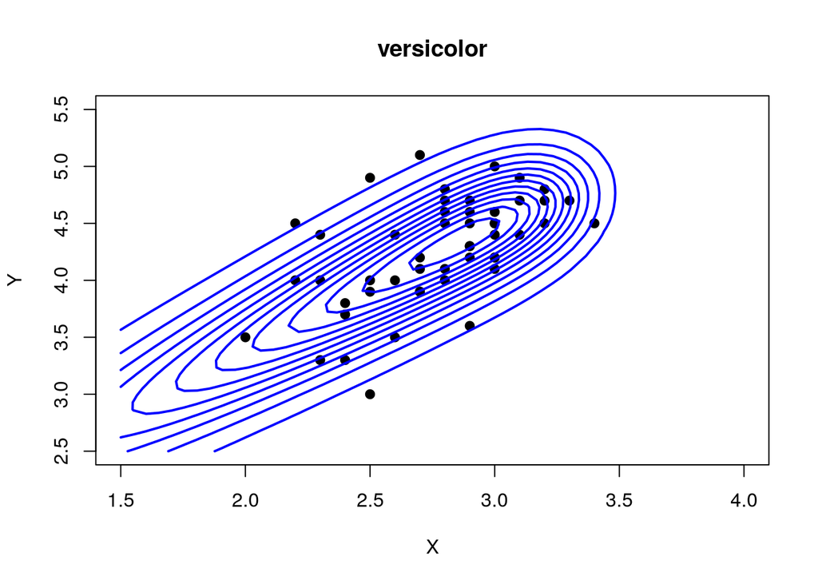

```r
###################################################
# Visualization of fitted contours - section 5.5  #
###################################################

fmcfust.contour.2d(iris.versicolor, Fit.versicolor, drawpoints = TRUE,
                   main = "versicolor", lwd = 2, xlim = c(1.5, 4),
                   ylim = c(2.5, 5.5), pcol = "black", ccol = "blue")
```

```r
obj <- list()
obj$mu <- list(matrix(c(0, 0, 0), 3), matrix(c(5, 5, 5), 3))
obj$sigma <- list(matrix(c(5, 2, 1, 2, 5, 1, 1, 1, 1), 3, 3), 2 * diag(3))
obj$delta <- list(matrix(c(1, 0, 0, 1, 0, 0, 1, 0, 0), 3, 3),
                  matrix(c(5, 0, 0, 0, 10, 0, 0, 0, 15), 3, 3))
obj$dof <- c(3, 3)
obj$pro <- c(0.2, 0.8)
```

Unfortunately markdown was unable to render 3d plots, so that part can’t be reproduced in HTML, altough the plots are well rendered in basic R. Computing, on the other hand, takes a lot of time, so I had to change number of iterations from 100 to 10, thus making the results not entirely exact as in source article. Despite these things, the article seems reproducible.